# Grand Mean Centering vs. Within-Cluster Centering Predictor Variables in Multilevel Models

## **Overview:**

### It is often recommended to center your predictor variables in a multilevel model. Researchers must decide whether-to and how-to center their variables such as picking between grand-mean centering and within-cluster centering. In this document, we will use a simulated Psychology data set and a dynamic plot to aid researchers’ understanding and decision-making on centering in multilevel models. The reader should have an introductory level understanding of what multilevel models are along with when and why these models are used.

## **Nested Data:**

#### It is not uncommon for data in Psychology to be nested. A nested data structure means that observations are not independent (i.e., observations are clustered into groups either intentionally or unintentionally). In the simulated data set below: We were interested in whether undergraduate Psychology students’ attitudes toward SPSS software affects their grades. We were also interested in whether the size of the school affects students’ grades so we collected data from a total of 50 students from 3 different schools. It is evident from the scatter plot below that our data is nested since students within a school are more similar to each other than students from a different school.

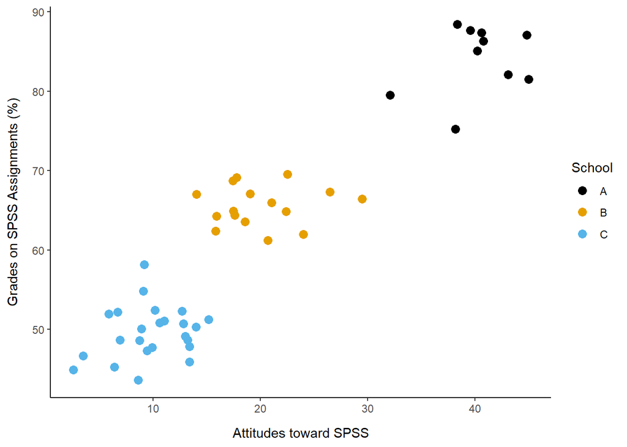

#### About the simulated data set: **ATSPSS:** sum score on Attitudes toward SPSS (ATSPSS) survey. Higher scores indicate more favourable attitudes toward SPSS. **grades:** a student’s average grade on all SPSS lab assignments in the course. **school_ID:** denotes the school the student belongs to. **stud_ID:** unique ID belonging to each student. **school_size:** categorical variable that denotes the size of the school, (0 = small, 1 = medium, 2 = big).

```r
colnames(df)
```

```
## [1] "ATSPSS"      "grades"      "school_ID"   "stud_ID"     "school_size"
```

```r
str(df)
```

```
## 'data.frame':    50 obs. of  5 variables:
##  $ ATSPSS     : num  40.6 43.1 38.2 32.1 40.2 ...
##  $ grades     : num  87.4 82.1 75.2 79.5 85.1 ...
##  $ school_ID  : chr  "A" "A" "A" "A" ...
##  $ stud_ID    : int  1 2 3 4 5 6 7 8 9 10 ...
##  $ school_size: chr  "0" "0" "0" "0" ...
```

```r
head(df)
```

```
##     ATSPSS   grades school_ID stud_ID school_size
## 1 40.59819 87.35671         A       1           0
## 2 43.06271 82.10706         A       2           0
## 3 38.16095 75.23466         A       3           0
## 4 32.06101 79.50295         A       4           0
## 5 40.23118 85.07153         A       5           0
## 6 38.33292 88.41935         A       6           0
```

```r
unique(df$school_ID)
```

```
## [1] "A" "B" "C"
```